# FJS scheduling problem with sequence flexibility considered

In the classical FJS scheduling problem, each operation can be processed by a subset of machines, situation known as **routing flexibility**. The FJS scheduling problem with sequence flexibility considered in Birgin et al. (2014) generalizes the classical FJS scheduling problem in the sense that **the linear order of the operations of a job is replaced by arbitrary precedence constraints given by a directed acyclic graph**. precedence constraints among **operations of a job** are given by an arbitrary directed acyclic graph (DAG). The flexibility of representing the precedences with a DAG instead of with a linear order (i.e. a single sequence) fits within the concept of sequence flexibility. Note that representing the precedences with a DAG also allows some operations of a job to be processed in parallel.

a precedence relation saying that an **operation i must be processed before an operation j is represented by an arc (i; j)** in a directed acyclic graph.

**In addition, several complicating particularities:**

- **periods of unavailability of the machines,** machines may be unavailable during some planned (i.e., known beforehand) time periods, being a consequence of pre-scheduling, maintenance, shift patterns, or overlapping of two consecutive time planning horizons.
- **resumable operations,** Operations can be interrupted by one or more unavailable periods, i.e., operations are resumable.the machine setup cannot be interrupted by unavailable periods;This means that the processing may be interrupted by a period of unavailability of the machine, but the processing of the operation must be resumed as soon as the machine returns to be available, i.e., the operation must remain on the machine until completion.
- **sequence-dependent setup times,**
- **partial overlapping among operations with precedence constraints,** The extent of this overlapping is limited by a fraction that defines the proportion of operation i that has to be processed before its successor j can start.
- **release times,**
- **fixed operations**

FJS scheduling problem with **sequence flexibility** and **process plan flexibility** is considered.

**the process plan flexibility** means that each job can be completed by performing one among several alternative sets of operations, each one with linear-order precedence constraints.

# Example

```python
import json
instance ='mops21 - Copy (2)' #'mops21 - Copy (3)' #'mops21 - Copy (2) - Copy' ##'sops1'#'mops21'#   #str(sys.argv[1]) mops20 - Copy
with open('instances/' + instance + '.json') as data_file:
        data = json.load(data_file)
print('running ' + instance)
```

```
running mops21 - Copy (2)
```

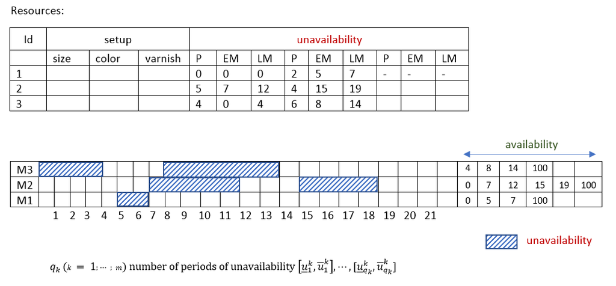

**Jobs:**

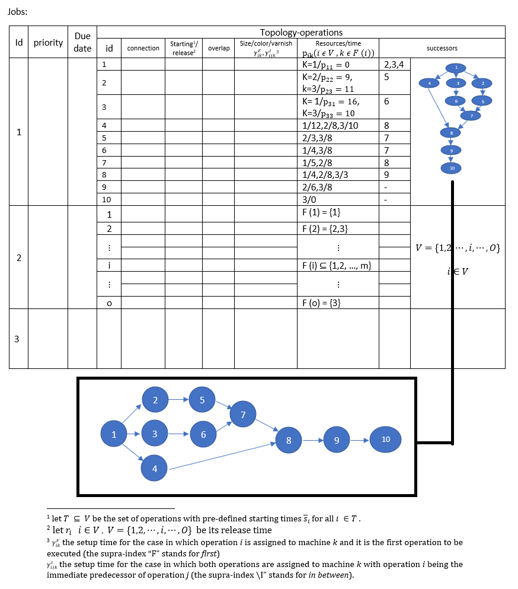

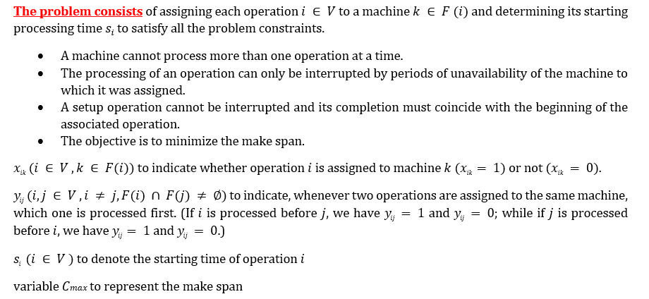

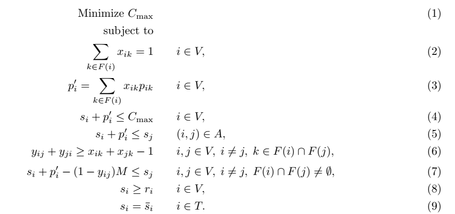

```python
from docplex.mp.model import Model
from docplex.mp.progress import ProgressListener
from docplex.util.environment import get_environment
terminal_output = False
running_time = 7200.0
mdl = Model(name='IJPE')
mdl.parameters.threads     = 1
mdl.parameters.mip.tolerances.mipgap    = float(0.0)
mdl.parameters.mip.tolerances.absmipgap = float(0.0)
```

Note that the decision variables in the model of the FJSSP should determine both the **assignment of the operation to the machines** and the **sequence of the operations on each machine**.

- **1-assignment of the operation to the machines**: x[i,k] (i Є V , k Є F(i)) to indicate whether operation i is assigned to machine k.

```python
n = sum(len(j["topology"]) for j in data["jobs"])# کل تعداد عملیات برای همه سفارش کار ها              # V=n
m = len(data["resources"])# تعداد ماشین ها
# the ith element stores the resources capable of processing the ith operation
M = [[m - 1 for m in o["resources"]] for j in data["jobs"] for o in j["topology"]]# لیست ماشین های مجاز برای انجام هر عملیات
print('لیست ماشین های مجاز:',M)                                                                         # M[i]=F[i]

X       = {(i, k)    : mdl.binary_var() for i in range(n) for k in M[i]}                            # x(ik)
```

```
لیست ماشین های مجاز: [[0], [1, 2], [0, 2], [0, 1, 2], [1, 2], [0, 2], [0, 1], [0, 1, 2], [1, 2]]
```

**Constraints (2)** say that each operation must be assigned to exactly one machine; **از مجموعه ماشین های کاندید برای هر عملیات یکی می تواند انجام شود**

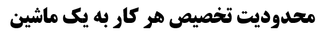

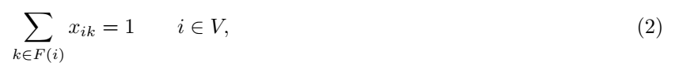

```python
# EQ: 2  each operation must be assigned to exactly one machine;
for i in range(n):
    mdl_sum = mdl.sum(X[i, k] for k in M[i])
    mdl.add_constraint(mdl_sum == 1)
```

**constraints (3)** define p'i as the processing time of operation i (that depends on the machine to which it was assigned.)

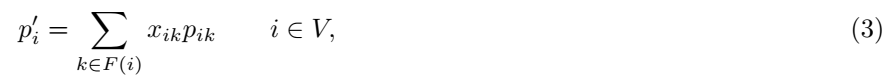

```python
# EQ: 3,10
p       = {i : mdl.continuous_var() for i in range(n)} # p¯(i) = sum(x(ik)p(ik)) زمان اجرای عملیات بر روی ماشین انتخاب شده

t = [o["time"] for j in data["jobs"] for o in j["topology"]]
print('زمان اجرای هر کار روی ماشین های مجاز مربوطه:',t)

for i in range(n):
    proc_sum = mdl.sum(X[i, M[i][k]] * t[i][k] for k in range(len(M[i])))                                   # EQ: 3
    mdl.add_constraint(p[i] == proc_sum)

    #proc_ov_sum = mdl.sum(X[i, M[i][g]] * math.ceil(overlap[i] * P[i][g]) for g in range(len(M[i])))        # EQ: 10
    #mdl.add_constraint(pbar[i] == proc_ov_sum)
```

```
زمان اجرای هر کار روی ماشین های مجاز مربوطه: [[0], [9, 11], [16, 10], [12, 8, 10], [3, 8], [4, 8], [5, 8], [4, 8, 3], [6, 8]]
```

**Constraints (5)** represent the classical meaning of a precedence constraint, saying that, independently of the machine by which they are being processed, if operation i precedes operation j, then i must be completed before j can be started.

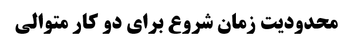

**si** (i Є V ) to denote the starting time of operation i

```python
s   = {i : mdl.continuous_var() for i in range(n)} # s(i)
```

let **A** be a set of operations pairs (i; j) representing precedence relations. (Note that, by definition, directed arcs in A correspond to independent directed acyclic graphs (DAG), each one representing the precedence relations among the operations of a job.)

```python
# EQ: 5 = if operation i precedes operation j, then i must be completed before j can be started.
A = [(o["id"] - 1, p - 1) for j in data["jobs"] for o in j["topology"] for p in o["sucessors"]]
print('لیست تقدم و تاخر فعالیت ها:',A)
for element in A:
    i = element[0]
    j = element[1]
    mdl.add_constraint(s[i]+p[i]<=s[j])
```

```
لیست تقدم و تاخر فعالیت ها: [(0, 1), (0, 2), (0, 3), (1, 4), (2, 5), (3, 7), (4, 6), (5, 6), (6, 7), (7, 8)]
```

- **Constraints (8)** say that each operation i can not start to be processed before its release time;
- **constraints (9)** fix the start time of the operations whose start times are already pre-determined.

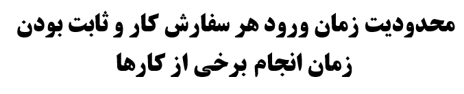

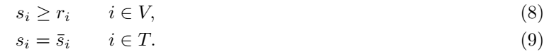

```python
# EQ: 8,9,31

# release time of the ith operation (release >= 0)
release = [o['release'] for j in data["jobs"] for o in j["topology"]]
# fixed starting time of the ith operation (-1 means not fixed)
fixstarting = [o['starting'] for j in data["jobs"] for o in j["topology"]]

for i in range(n):
    # Release time
    mdl.add_constraint(s[i] >= release[i])        # EQ: 8
    # Full setup time
    if fixstarting[i] > -1:
        mdl.add_constraint(s[i] == fixstarting[i])  # EQ: 9

    #mdl.add_constraint(start[i] >= xi[i])             # EQ: 31
    # Fixed Operations
```

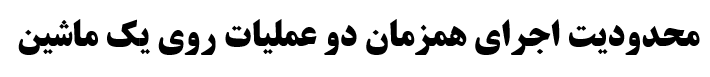

**binary variables y[i,j] (i, j Є V , i ≠ j, F(i) ∩ F(j) ≠ ɸ)** to indicate, whenever two operations are assigned to the same machine, which one is processed first. (If i is processed before j, we have y[i,j] = 1 and y[j,i] = 0; while if j is processed before i, we have y[j,i] = 1 and y[i,j] = 0.)

اگر برای اجرای دو عملیات ماشین مشترکی وجود داشته باشد

```python
Y={}
#var_count=0
for i in range(n):
    for j in range(n):
        if i != j:
            #has_one = False # True if exist machine k which proc. i and j
            #for machine in M[i]:
            #    if machine in M[j]:
            #        has_one = True
            #if has_one:
            for k in range(m):
                if k in M[i] and k in M[j]:
                    Y[(i, j)]= mdl.binary_var()
                    #var_count += 1
print(Y)
#print(var_count)

# Transitive reduction
#B = []
#for k in range(m):
#    processed_by_k = []
#    for i in range(n):
#        if k in M[i]:
#            processed_by_k.append(i)
#    B.append(processed_by_k)
#print('لیست عملیات هایی که هر ماشین مجاز به اجرای آنها می باشد:',B)
# Y       = {(i, j, k) : mdl.binary_var() for k in range(m) for i in B[k] for j in B[k] if i != j}  # y(i,j,k)
# Y       = {(i, j) : mdl.binary_var()  for i in B[k] for j in B[k] if i != j}           # y(i,j)
```

[output not shown]

**Constraints (6) and (7)** deal with pairs of operations i and j that are assigned to the same machine k.A machine cannot process more than one operation at a time.

- **constraints (6)** say that if i and j were assigned to the same machine k, then i must be processed before j or j must be processed before i, i.e., an order must be established.
- **constraints (7)** say that if i and j were assigned to the same machine k and i is processed before j, then between the starting times of i and j there must be enough time to process i.

**وقتی دو فعالیت روی یک ماشین انجام می شوند حداقل باید یکی جلوتر از دیگری باشد**

```python
# EQ: 6
#constraint_count=0
for i in range(n):
    for j in range(n):
        if i != j:
            has_one = False # True if exist machine k which proc. i and j
            for machine in M[i]:
                if machine in M[j]:
                    has_one = True

            if has_one:
                for k in range(m):
                    if k in M[i] and k in M[j]:
                        mdl.add_constraint(Y[i,j] + Y[j,i]>= X[i,k] + X[j,k] - 1)
                        #print('i:' + str(i) + ',j:' + str(j) +',k:' + str(k))
                        #constraint_count+= 1
#print(constraint_count)

# final_list = sorted(lst1 + lst2)
#for k in range(m):
#    for i in B[k]:
#        for j in B[k]:
#            if i != j:
#                Y[i,j]+Y[j,i]>= X[i,k]+X[j,k] -1
```

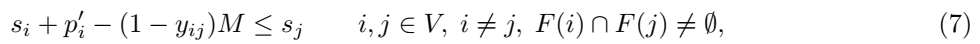

```python
# EQ:  7  and 29  Completed of 7 and 18 and 25

U = [k["availability"] for k in data["resources"]]
print('U:',U)
for k in range(m):
    print(len(U[k]) // 2)
avs = [[[U[k][2 * v], U[k][2 * v + 1]] for v in range(len(U[k]) // 2)] for k in range(m)]
print(avs)
unavs = []
id_unav = 0
for k in range(m):
    unavs_in_k = []
    if U[k][0] > 0:
        unavs_in_k.append((0, U[k][0], k))
        id_unav += 1
    for v in range(2, len(U[k]), 2):
        unavs_in_k.append((U[k][v - 1], U[k][v], k))
        id_unav += 1
    unavs.append(unavs_in_k)
print(unavs)
linear_unavs = [unav for unav_in_k in unavs for unav in unav_in_k]
print(linear_unavs)

rightSum = 0
for i in range(n):
    max_value = 0
    for g in range(len(M[i])):
        max_value = max(max_value, t[i][g]) # + get_full_setup(M[i][g])
    rightSum += max_value # + get_full_setup(k)
print(rightSum)

latestUnav = 0
for k in range(m):
    for unav in unavs[k]:
        latestUnav = max(latestUnav, unav[1])
print(latestUnav)

MM=latestUnav+rightSum
print(MM)
#MM =sum(P[i][j] for i in range(n) for j in range(len(M[i]))) + sum(PM[i][l] for i in range(m) for l in range(len(unavs[k])))
#print(MM)
for i in range(n):
    for j in range(n):
        if i != j:
            has_one = False # True if exist machine k which proc. i and j
            for machine in M[i]:
                if machine in M[j]:
                    has_one = True

            if has_one:
                for k in range(m):
                    if k in M[i] and k in M[j]:
                        mdl.add_constraint(s[i]+p[i]-((1-Y[i,j]) * MM ) <=s[j])
                        # mdl.add_constraint(s[j]+p[j]-(Y[i,j] * MM ) <=s[i])  # set of disjunctive constraints ensure that
                                                                               # only one job is processing at a given time
                                                                               # in a given machine
                #sumy = mdl.sum(Y[i, j, k] for k in range(m) if k in M[i] and k in M[j])
                #mdl.add_constraint(comp[i] - (1 - sumy) * bigM2 <= start[j] - xi[j])
```

```
U: [[0, 5, 7, 100], [0, 7, 12, 15, 19, 100], [4, 8, 14, 100]]
2
3
2
[[[0, 5], [7, 100]], [[0, 7], [12, 15], [19, 100]], [[4, 8], [14, 100]]]
[[(5, 7, 0)], [(7, 12, 1), (15, 19, 1)], [(0, 4, 2), (8, 14, 2)]]
[(5, 7, 0), (7, 12, 1), (15, 19, 1), (0, 4, 2), (8, 14, 2)]
79
19
98
```

variable Cmax to represent the makespan.

```python
Cmax    = mdl.continuous_var(name='CMAX')
```

**Constraints (4)** ensure that every operation is not completed later than Cmax.

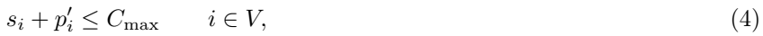

```python
# EQ: 4
for i in range(n):
    mdl.add_constraint(s[i]+p[i]<=Cmax)
```

```python
# objective function
mdl.add_kpi(Cmax, publish_name="MakeSpan:")
mdl.minimize(Cmax)
```

```python
mdl.print_information()
```

```
Model: IJPE
 - number of variables: 140
   - binary=121, integer=0, continuous=19
 - number of constraints: 250
   - linear=250
 - parameters:
     parameters.threads = 1
     parameters.mip.tolerances.absmipgap = 0.00000000000000
     parameters.mip.tolerances.mipgap = 0.00000000000000
 - objective: minimize
 - problem type is: MILP
```

```python
mdl.solve()
mdl.print_solution()
```

```
objective: 29.000
  x1=1
  x2=1
  x5=1
  x8=1
  x9=1
  x11=1
  x13=1
  x17=1
  x18=1
  x21=9.000
  x22=10.000
  x23=10.000
  x24=3.000
  x25=4.000
  x26=5.000
  x27=3.000
  x28=6.000
  x32=10.000
  x33=9.000
  x34=10.000
  x35=14.000
  x36=20.000
  x37=23.000
  x38=1
  x39=1
  x40=1
  x41=1
  x45=1
  x47=1
  x53=1
  x57=1
  x60=1
  x63=1
  x78=1
  x80=1
  x87=1
  x91=1
  x99=1
  x111=1
  x128=1
  CMAX=29.000
```

```
s[1]: x29 0
x[1]: x1 1.0
s[2]: x30 0
x[2]: x2 1.0
x[3]: x3 0
s[3]: x31 0
x[1]: x4 0
x[3]: x5 1.0
s[4]: x32 9.999999999999968
x[1]: x6 0
x[2]: x7 0
x[3]: x8 1.0
s[5]: x33 9.0
x[2]: x9 1.0
x[3]: x10 0
s[6]: x34 9.999999999999995
x[1]: x11 1.0
x[3]: x12 0
s[7]: x35 13.999999999999995
x[1]: x13 1.0
x[2]: x14 0
s[8]: x36 19.999999999999957
x[1]: x15 0
x[2]: x16 0
x[3]: x17 1.0
s[9]: x37 22.999999999999943
x[2]: x18 1.0
x[3]: x19 0
```

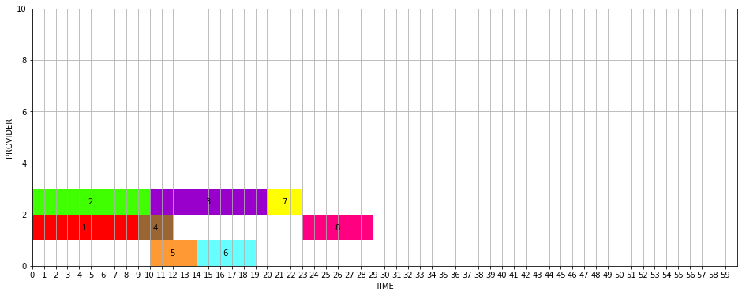

```
Y[1,3] 1.0 X[1,1] 1.0 X[3,1] 0
Y[1,4] 1.0 X[1,1] 1.0 X[4,1] 0
Y[1,6] 1.0 X[1,1] 1.0 X[6,1] 1.0
Y[1,7] 1.0 X[1,1] 1.0 X[7,1] 1.0
Y[1,8] 0 X[1,1] 1.0 X[8,1] 0
Y[2,3] 0 X[2,3] 0 X[3,3] 1.0
Y[2,4] 1.0 X[2,2] 1.0 X[4,2] 0
Y[2,4] 1.0 X[2,3] 0 X[4,3] 1.0
Y[2,5] 1.0 X[2,2] 1.0 X[5,2] 1.0
Y[2,5] 1.0 X[2,3] 0 X[5,3] 0
Y[2,6] 0 X[2,3] 0 X[6,3] 0
Y[2,7] 0 X[2,2] 1.0 X[7,2] 0
Y[2,8] 0 X[2,2] 1.0 X[8,2] 0
Y[2,8] 0 X[2,3] 0 X[8,3] 1.0
Y[2,9] 1.0 X[2,2] 1.0 X[9,2] 1.0
Y[2,9] 1.0 X[2,3] 0 X[9,3] 0
Y[3,1] 0 X[3,1] 0 X[1,1] 1.0
Y[3,2] 0 X[3,3] 1.0 X[2,3] 0
Y[3,4] 1.0 X[3,1] 0 X[4,1] 0
Y[3,4] 1.0 X[3,3] 1.0 X[4,3] 1.0
Y[3,5] 0 X[3,3] 1.0 X[5,3] 0
Y[3,6] 1.0 X[3,1] 0 X[6,1] 1.0
Y[3,6] 1.0 X[3,3] 1.0 X[6,3] 0
Y[3,7] 0 X[3,1] 0 X[7,1] 1.0
Y[3,8] 1.0 X[3,1] 0 X[8,1] 0
Y[3,8] 1.0 X[3,3] 1.0 X[8,3] 1.0
Y[3,9] 0 X[3,3] 1.0 X[9,3] 0
Y[4,1] 0 X[4,1] 0 X[1,1] 1.0
Y[4,2] 0 X[4,2] 0 X[2,2] 1.0
Y[4,2] 0 X[4,3] 1.0 X[2,3] 0
Y[4,3] 0 X[4,1] 0 X[3,1] 0
Y[4,3] 0 X[4,3] 1.0 X[3,3] 1.0
Y[4,5] 0 X[4,2] 0 X[5,2] 1.0
Y[4,5] 0 X[4,3] 1.0 X[5,3] 0
Y[4,6] 0 X[4,1] 0 X[6,1] 1.0
Y[4,6] 0 X[4,3] 1.0 X[6,3] 0
Y[4,7] 0 X[4,1] 0 X[7,1] 1.0
Y[4,7] 0 X[4,2] 0 X[7,2] 0
Y[4,8] 1.0 X[4,1] 0 X[8,1] 0
Y[4,8] 1.0 X[4,2] 0 X[8,2] 0
```

[output cut: 47 more lines]

```
Y[8,7] 0 X[8,1] 0 X[7,1] 1.0
Y[8,7] 0 X[8,2] 0 X[7,2] 0
Y[8,9] 1.0 X[8,2] 0 X[9,2] 1.0
Y[8,9] 1.0 X[8,3] 1.0 X[9,3] 0
Y[9,2] 0 X[9,2] 1.0 X[2,2] 1.0
Y[9,2] 0 X[9,3] 0 X[2,3] 0
Y[9,3] 0 X[9,3] 0 X[3,3] 1.0
Y[9,4] 0 X[9,2] 1.0 X[4,2] 0
Y[9,4] 0 X[9,3] 0 X[4,3] 1.0
Y[9,5] 0 X[9,2] 1.0 X[5,2] 1.0
Y[9,5] 0 X[9,3] 0 X[5,3] 0
Y[9,6] 0 X[9,3] 0 X[6,3] 0
Y[9,7] 0 X[9,2] 1.0 X[7,2] 0
Y[9,8] 0 X[9,2] 1.0 X[8,2] 0
Y[9,8] 0 X[9,3] 0 X[8,3] 1.0
```

```python
import matplotlib.pyplot as plt
fig, gnt = plt.subplots(1, figsize=(16,6))
gnt.set_ylim(0, 10)
gnt.set_xlim(0,60)
gnt.set_xticks(range(0, 60,1))
gnt.set_xlabel('TIME')
gnt.set_ylabel('PROVIDER')
#gnt.set_yticks(df.INDEX)
#gnt.set_yticklabels(df.NAME)
gnt.grid(True)
colors = ['#ff0000','#40ff00','#9900cc','#996633','#ff9933','#66ffff','#ffff00','#ff0080','#33cc33','#0000ff',]
for i in range(n):
    print('s['+ str(i+1) + ']:' ,s[i],s[i].solution_value)
    for g,k in enumerate(M[i]):
        print('x['+ str(k+1) + ']:' ,X[i, k], X[i, k].solution_value)
        if X[i, k].solution_value !=  0:
            ss_c= colors[i-1]
            mm= s[i].solution_value
            nn= (( t[i][g] )/2)-0.25 # s[i].solution_value +
            c= k+0.4
            gnt.broken_barh([(s[i].solution_value, t[i][g])], (k,1) , facecolors =ss_c) # s[i].solution_value +
        #print(ss_c)
            if k==0 and i==0 or k==2 and i==9:
                gnt.text(mm + nn,c,str('') )
            else:
                # gnt.text(mm + nn,c,str(k+1)+str(i+1) )
                gnt.text(mm + nn,c,str(i))#str(k+1)+#str('T')+ 'str(i+1)
#for i in range(m):
#    for jj in range(len(linear_unavs)):
#            if linear_unavs[jj][2] == i:
#                gnt.broken_barh([(linear_unavs[jj][0], linear_unavs[jj][1] - linear_unavs[jj][0])], (i, 1), facecolors ='#e6e6e6', hatch='///',label=j* (j+1)) #'#000000',text=index
plt.show()
for i in range(n):
    for j in range(n):
        if i != j:
            #has_one = False # True if exist machine k which proc. i and j
            #for machine in M[i]:
            #    if machine in M[j]:
            #        has_one = True
            #if has_one:
            for k in range(m):
                if k in M[i] and k in M[j]:
                    print('Y[' + str(i+1)+ ','+ str(j+1) + ']',  Y[i, j].solution_value ,'X[' + str(i+1)+ ','+ str(k+1) + ']',X[i, k].solution_value,'X[' + str(j+1)+ ','+ str(k+1) + ']',X[j, k].solution_value )
```